# Improving Yelp Users’ Experience

# Using Yelp Dataset

### Feb 28, 2020

Yelp is one of the most widely used local business review software worldwide that millions of people use it to discover and review local businesses. It is so widely used that it helps 184 millions of consumers see which businesses are available in their area and how each one has performed for their clients and Yelp.com is the 44th most visited website in the US according to Alexa. However, it has been accused of using unfair practices to raise revenue from the businesses that are reviewed on its site, for example, by presenting more negative review information for companies that do not purchase its advertising services, and also there are many fake positive reviews on Yelp. Besides that, since Yelp only provides a general view about businesses, such as an overall score and a large number of reviews. Unless people have enough time and patience to read all the reviews, otherwise it will be hard for users to know the details of the business.  
As an user of Yelp, I have a deep understanding of some weak points of this software. So by diving deep into Yelp Dataset, I can give some advice and find information that better satisfies their preference for people who use this software to discover businesses to improve their experience when using Yelp to find some useful information to them.

## About the Data

In this report, I will use data from Yelp Dataset Challenge. According to Term of Use, we have the right to access and use the data if it is for academic use. And for other non-academic purposes, we may not use it without Yelp's prior written consent, and we cannot encourage, assist, or enable others to display or use data to create business listing information; or use it for commercial purposes; or use it that violates laws; or use it on behalf of third party; or rent, lease, modify, comment on the content; or display it in a way that disparages Yelp. So for this report, I downloaded JSON files. It contains business.json, checkin.json, photo.json, review.json, and in this report, I will use business.json and review.json. First, I loaded them into dataframes.  
'business.json' is loaded as 'business_df'. Each row contains a unique business, and there are 192,609 businesses in total. And business_df contains the following columns:

- business_id: 22 character unique id for each business
- name: name of the business
- address: full address of the business
- city: the city where the business is located
- state: 2 character state code of the state where the business is located
- postal_code: postal code of the business
- latitude: latitude of the business
- longitude: longitude of the business
- stars: star rating of the business, rounded to half-stars
- review_count: number of reviews
- is_open: 0 or 1 for closed or open, respectively
- attributes: business attributes
- categories: business categories
- hours: open hours of the business, in the format of "day": "hour-hour", hours are using a 24hr clock

|  | business_id | name | address | city | state | postal_code | latitude | longitude | stars | review_count | is_open | attributes | categories | hours |
| --- | --- | --- | --- | --- | --- | --- | --- | --- | --- | --- | --- | --- | --- | --- |
| 0 | 1SWheh84yJXfytovILXOAQ | Arizona Biltmore Golf Club | 2818 E Camino Acequia Drive | Phoenix | AZ | 85016 | 33.522143 | -112.018481 | 3.0 | 5 | 0 | {'GoodForKids': 'False'} | Golf, Active Life | None |
| 1 | QXAEGFB4oINsVuTFxEYKFQ | Emerald Chinese Restaurant | 30 Eglinton Avenue W | Mississauga | ON | L5R 3E7 | 43.605499 | -79.652289 | 2.5 | 128 | 1 | {'RestaurantsReservations': 'True', 'GoodForMe... | Specialty Food, Restaurants, Dim Sum, Imported... | {'Monday': '9:0-0:0', 'Tuesday': '9:0-0:0', 'W... |
| 2 | gnKjwL_1w79qoiV3IC_xQQ | Musashi Japanese Restaurant | 10110 Johnston Rd, Ste 15 | Charlotte | NC | 28210 | 35.092564 | -80.859132 | 4.0 | 170 | 1 | {'GoodForKids': 'True', 'NoiseLevel': 'u'avera... | Sushi Bars, Restaurants, Japanese | {'Monday': '17:30-21:30', 'Wednesday': '17:30-... |
| 3 | xvX2CttrVhyG2z1dFg_0xw | Farmers Insurance - Paul Lorenz | 15655 W Roosevelt St, Ste 237 | Goodyear | AZ | 85338 | 33.455613 | -112.395596 | 5.0 | 3 | 1 | None | Insurance, Financial Services | {'Monday': '8:0-17:0', 'Tuesday': '8:0-17:0', ... |

'review.json' is loaded as 'review_df'. Each row contains a unique review, and there are 6,685,900 reviews in total. And review_df contains the following columns:

- review_id: 22 character unique review id
- user_id: 22 character unique user id
- business_id: 22 character business id, maps to business in business.json
- stars: star rating
- useful: number of useful votes received
- funny: number of funny votes received
- cool: number of cool votes received
- text: the review itself
- date: date formatted YYYY-MM-DD

Since the business_id in review.json maps to business in business.json, so we can get the information of the business for a specific review by business_id.

|  | review_id | user_id | business_id | stars | useful | funny | cool | text | date |
| --- | --- | --- | --- | --- | --- | --- | --- | --- | --- |
| 0 | Q1sbwvVQXV2734tPgoKj4Q | hG7b0MtEbXx5QzbzE6C_VA | ujmEBvifdJM6h6RLv4wQIg | 1.0 | 6 | 1 | 0 | Total bill for this horrible service? Over $8G... | 2013-05-07 04:34:36 |
| 1 | GJXCdrto3ASJOqKeVWPi6Q | yXQM5uF2jS6es16SJzNHfg | NZnhc2sEQy3RmzKTZnqtwQ | 5.0 | 0 | 0 | 0 | I *adore* Travis at the Hard Rock's new Kelly ... | 2017-01-14 21:30:33 |
| 2 | 2TzJjDVDEuAW6MR5Vuc1ug | n6-Gk65cPZL6Uz8qRm3NYw | WTqjgwHlXbSFevF32_DJVw | 5.0 | 3 | 0 | 0 | I have to say that this office really has it t... | 2016-11-09 20:09:03 |
| 3 | yi0R0Ugj_xUx_Nek0-_Qig | dacAIZ6fTM6mqwW5uxkskg | ikCg8xy5JIg_NGPx-MSIDA | 5.0 | 0 | 0 | 0 | Went in for a lunch. Steak sandwich was delici... | 2018-01-09 20:56:38 |

# Standardization

## Fix incorrect city names

I have noticed that there are many cities with small counts in the business_df. And then I took a look at those cities, and the table below shows some of these cities.

```
Cote Saint Luc      1
River Drive Park    1
Mt. Washington      1
Northyork           1
Montéal             1
Phoneix             1
South Russell       1
Cuyohoga Falls      1
Bradfordwoods       1
                    1
Name: city, dtype: int64
```

'North Toronto' should be 'Toronto' and 'Northeast Calgary' should be 'Calgary'. This indicates that some cities are not stored in standard format of city name in business_df. Since using FuzzyWuzzy to fix the city names cannot detect all the incorrect city names, and there are still many names that cannot be matched. So I chose to use the latitude and longitude to find the name of the city and stored the new name in 'city' column. Since the cities whose number of counts are less than 10 are more likely to be the cities with incorrect name, so I fixed the name of the cities with counts less than 10.

This is the dataframe after fixing possible incorrect city names.

|  | business_id | name | address | city | state | postal_code | latitude | longitude | stars | review_count | is_open | attributes | categories | hours |
| --- | --- | --- | --- | --- | --- | --- | --- | --- | --- | --- | --- | --- | --- | --- |
| 0 | fweCYi8FmbJXHCqLnwuk8w | Marco's Pizza | 5981 Andrews Rd | Lake County | OH | 44060 | 41.708520 | -81.359556 | 4.0 | 16 | 1 | {'RestaurantsPriceRange2': '2', 'BusinessAccep... | Italian, Restaurants, Pizza, Chicken Wings | {'Monday': '10:0-0:0', 'Tuesday': '10:0-0:0', ... |
| 1 | TNtzvDcY20ueBMz9mG_JeA | Rock Of Ages | 7238 E Main St | Scottsdale | AZ | 85251 | 33.493231 | -111.925144 | 4.0 | 4 | 1 | None | Psychic Mediums, Jewelry, Shopping, Psychics, ... | {'Monday': '9:0-18:0', 'Tuesday': '9:0-18:0', ... |
| 2 | yxAw_NtCqtvFPXGq4C1f5A | The Cedar Kitchen | 5 Queen Street S | New Tecumseth | ON | L0G 1W0 | 44.022253 | -79.805450 | 4.0 | 12 | 1 | {'RestaurantsReservations': 'False', 'Restaura... | Restaurants | None |
| 3 | 8ELlbjnXfZAw4KbQRP3-EQ | Tomate Basilic | 12585 Sherbrooke Rue E | Montréal | QC | H1B 1C8 | 45.650994 | -73.512000 | 4.0 | 8 | 1 | {'RestaurantsDelivery': 'False', 'Alcohol': 'u... | Italian, Restaurants | None |
| 4 | brR5W9tv7kwg6ElslwvwKw | My Cheesecake Addiction |  | Calgary | AB | T3A 2M4 | 51.117679 | -114.149150 | 5.0 | 3 | 1 | {'RestaurantsPriceRange2': '2'} | Home Services, Patisserie/Cake Shop, Food, Des... | {'Friday': '10:0-17:0', 'Saturday': '10:0-17:0... |

```
Las Vegas     29384
Toronto       18963
Phoenix       18810
Charlotte      9535
Scottsdale     8864
Calgary        7755
Pittsburgh     7071
Montréal       6519
Mesa           6083
Henderson      4912
Name: city, dtype: int64
```

## Make Dataframes for businesses in GTA and reviews on GTA businesses

Since in the analysis, I will mainly focus on the businesses in Greater Toronto Area (GTA) and the reviews on GTA businesses, so I select all the businesses in GTA, and all reviews on GTA businesses based on business_id.

These are some rows in the dataframe for businesses in GTA.

|  | business_id | name | address | city | state | postal_code | latitude | longitude | stars | review_count | is_open | attributes | categories | hours |
| --- | --- | --- | --- | --- | --- | --- | --- | --- | --- | --- | --- | --- | --- | --- |
| 2 | yxAw_NtCqtvFPXGq4C1f5A | The Cedar Kitchen | 5 Queen Street S | New Tecumseth | ON | L0G 1W0 | 44.022253 | -79.805450 | 4.0 | 12 | 1 | {'RestaurantsReservations': 'False', 'Restaura... | Restaurants | None |
| 13 | 8r8-R4dxsbrif9DRAUcDXw | Massimo Dutti - Yorkdale | 3401 Dufferin Street | Toronto | ON | M6A 2T9 | 43.724684 | -79.454173 | 2.0 | 4 | 1 | {'BusinessParking': '{'garage': False, 'street... | Women's Clothing, Men's Clothing, Shopping, Fa... | {'Monday': '9:0-18:0', 'Tuesday': '9:0-18:0', ... |
| 35 | CXIYPBfADfeOAfYJSPAs1A | The Manor | 16750 Weston Road, Unit A | King | ON | L7B 0C7 | 44.007103 | -79.602347 | 3.5 | 14 | 1 | {'RestaurantsPriceRange2': '3', 'OutdoorSeatin... | Restaurants, Breakfast & Brunch, Event Plannin... | {'Monday': '9:0-20:0', 'Tuesday': '9:0-20:0', ... |

These are some rows in the dataframe for reviews on GTA businesses.

|  | review_id | user_id | business_id | stars | useful | funny | cool | text | date |
| --- | --- | --- | --- | --- | --- | --- | --- | --- | --- |
| 6 | G7XHMxG0bx9oBJNECG4IFg | jlu4CztcSxrKx56ba1a5AQ | 3fw2X5bZYeW9xCz_zGhOHg | 3.0 | 5 | 4 | 5 | Tracy dessert had a big name in Hong Kong and ... | 2016-05-07 01:21:02 |
| 14 | JVcjMhlavKKn3UIt9p9OXA | TpyOT5E16YASd7EWjLQlrw | AakkkTuGZA2KBodKi2_u8A | 1.0 | 1 | 1 | 0 | I cannot believe how things have changed in 3 ... | 2012-07-16 00:37:14 |
| 15 | svK3nBU7Rk8VfGorlrN52A | NJlxGtouq06hhC7sS2ECYw | YvrylyuWgbP90RgMqZQVnQ | 5.0 | 0 | 0 | 0 | You can't really find anything wrong with this... | 2017-04-07 21:27:49 |

# Data Overview

Before moving to analyze the specific questions that users may concern, first, I want to give an overview of the data, and the scope of application of this analysis.

## All the Cities which the Dataset Encompass

I selected all the unique cities in the dataset, and plot them on the map based on their latitudes and longitudes.

[figure not shown]

From the map, we can see that all businesses in this dataset are in the US and Canada. And surprisingly, the dataset does not cover most cities in these two countries, instead, it only covers some regions. And most businesses are concentrated in some regions. These cities or regions are Montreal, Toronto, Las Vegas, Phoenix, Charlotte, Champaign, Cleveland, Madison, Pittsburgh and Calgary. One possible reason for this is that this dataset only includes a subset of the businesses, so maybe these cities and regions are selected to be included in this dataset.

## The Most Popular Categories

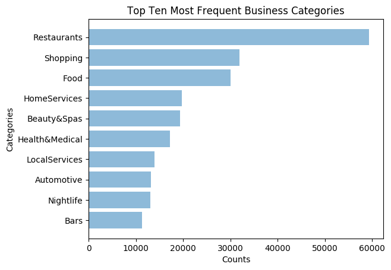

From the bar plot, the count for restaurants is far greater than other categories and the second one is shopping, and the third most popular category is food, which is also relative to restaurants. So restaurants take a large proportion in the whole dataset of businesses.

Will there be any difference for the most frequent business categories in GTA?

|  | counts | category | rank_in_GTA | rank_in_whole_df |
| --- | --- | --- | --- | --- |
| 1 | 14476 | Restaurants | 1 | 1 |
| 2 | 6972 | Food | 2 | 3 |
| 3 | 5029 | Shopping | 3 | 2 |
| 4 | 3257 | Beauty&Spas | 4 | 5 |
| 5 | 2471 | Nightlife | 5 | 9 |
| 6 | 2193 | Bars | 6 | 10 |
| 7 | 2050 | Coffee&Tea | 7 | 15 |
| 8 | 1619 | Chinese | 8 | 35 |
| 9 | 1617 | Health&Medical | 9 | 6 |
| 10 | 1575 | EventPlanning&Services | 10 | 11 |

From the table above, the top 10 most popular categories are very similar between GTA and the whole dataset. But there still are some differences in GTA. The ranks of Nightlife and Bars are higher in GTA, and also it seems that people in Toronto like coffee and cafe. The biggest change is that the rank of Chinese food is greatly higher in GTA and this is mainly due to the large number of Chinese immigrants and students in GTA. Also, it is interesting that it seems that people in GTA love food very much because 4 categories of the top 10 are about food in GTA and only 2 are about food in the whole dataset. Maybe that is reason why Toronto is top 50 best food cities

By overviewing the data, my analysis and conclusion should have more reference value for users in regions like Montreal, Toronto, Las Vegas, Phoenix, Charlotte, Champaign, Cleveland, Madison, Pittsburgh and Calgary, since these are the regions that the dataset mainly cover. Also, for users who want to explore restaurants and food, this analysis is useful to you, because categories related with food take a great proportion in the whole dataset and in data for GTA.

Also, here are some advice for people viewing this report. If you love food, especially Chinese food, GTA is a great place in North America for you to taste good Chinese food. Also, if you travel to GTA, do not miss the cafes, bars and nightlife in GTA.

# Analysis and Visualizations

## Businesses with Bike Parking

Approximately 20 percent of the population in GTA are utilitarian cyclists, riding to work and school, going shopping, or going to restaurants. And we can see that in the whole dataset, Toronto ranks second by number of businesses with bike parking, and it is only a few less than the number in Las Vegas.

```
Las Vegas     8653
Toronto       8646
Phoenix       5557
Charlotte     3297
Scottsdale    3024
Name: city, dtype: int64
```

*table for top 5 cities with most businesses with bike parking*

If you are a cyclist, and often ride to go shopping or go to restaurants, but most time you are afraid of having no place to park bike. So what kind of businesses have bike parking really matters to those cyclists.

|  | name | categories | RestaurantsPriceRange2 | BusinessAcceptsCreditCards | GoodForKids | OutdoorSeating | RestaurantsTakeOut | RestaurantsReservations | WiFi | Smoking | HasTV | NoiseLevel | ByAppointmentOnly |
| --- | --- | --- | --- | --- | --- | --- | --- | --- | --- | --- | --- | --- | --- |
| 0 | Starbucks | Food,Coffee&Tea | 2 | True | True | False | True | False | u'free' | u'no' | True | u'average' | False |

Starbucks has the most number of counts among all businesses that have bike parking. So for those cyclists, a good place for having a drink or food is Starbucks, because it provides bike parking. And also, cyclists do not need to worry about where to eat if they ride to the restaurants, because most businesses with bike parking provide free wifi, and TVs, the price and noise level are also on average, and accepts credit cards and take out.

## Choosing between Starbucks and Tim Hortons

GTA has a great number of places for coffee since 'Coffee&Tea' is top 10 most popular categories in GTA. When people think of places for Coffee&Tea, Starbucks and Tim Hortons are two options that most people would make choice between them.

```
Tim Hortons           282
Starbucks             257
McDonald's            142
Shoppers Drug Mart     99
Pizza Pizza            92
Name: name, dtype: int64
```

*table for top 5 franchises in GTA*

Not surprisingly, Starbucks and Tim Hortons are the top 2 franchises in GTA. But since they are very similar in the items they sell and similar in price range, so sometimes it would be difficult for people to decide where to go. The first possible thing that people consider might be location.

### Location

[figure not shown]

From the map of all the Starbucks and Tim Horton's, it seems that for most Starbucks in GTA, there is a Tim Hortons nearby, and the distance between the two groups seem to be very small. So to further see the distance between them, I calculated the distance between each Starbucks and its nearest Tim Hortons. I iterated every Starbucks and found its nearest Tim Hortons, and then I calculated the distance between them.

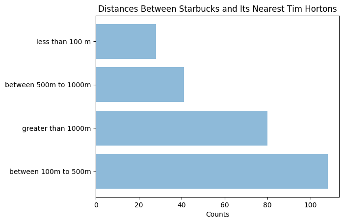

For more than 100 Starbucks, its distance from its nearest Tim Hortons is between 100m and 500m, and the distance between the two groups are mostly below 1km. So location does not play a big role for people when choosing from Tim Hortons and Starbucks, since people can almost always find a Tim Hortons or Starbucks nearby.

### Good and bad aspects

Review is a good way to see whether people are satisfied with the business or not. So I dive deep into people's review on Starbucks and Tim Hortons to see what people are satisfied or dissatisfied with the two businesses. First, I need to select all the reviews on Tim Hortons or Starbucks, and I will use business_id to detect whether a review is about the two groups or not.

Then, to identify whether people talk more about their satisfactions or dissatisfactions in their reviews, I calculated sentimental scores for each review. And reviews with negative sentimental score are considered as reviews about bad aspects of the business, while reviews with positive sentimental score are considered as reviews about good aspect.

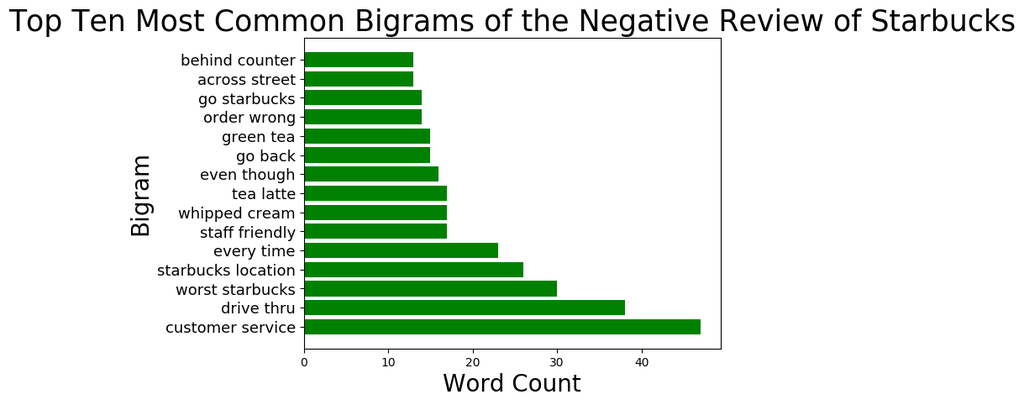

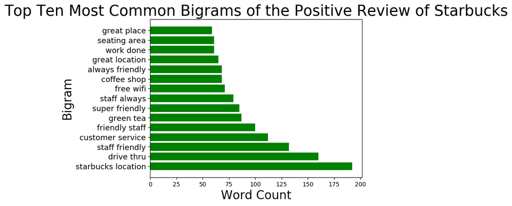

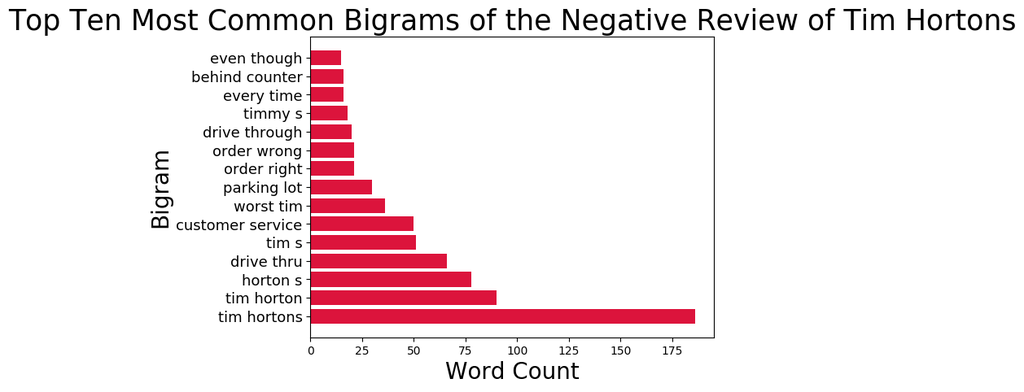

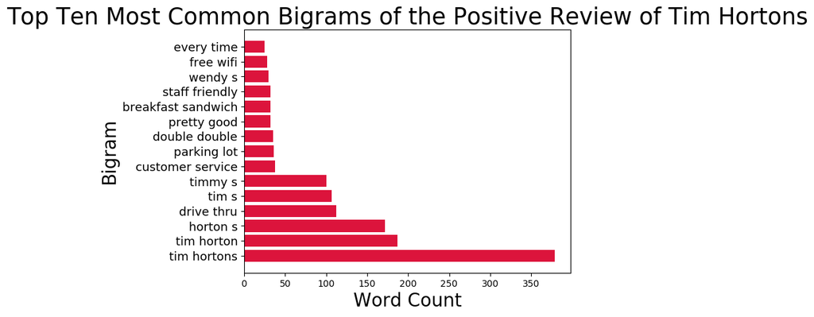

From the 4 bar plots above, reviewers seem to use very similar words in their reviews of GTA's Tim Horton's and Starbucks. In the negative reviews, they all use words like "worst XXX", and one main reason they are not satisfied is "wrong order". And in the positive reviews, people are satisfied with Tim Hortons or Starbucks because of "free wifi", "friendly staff", "good customer service", "drive thru". However, "green tea" appears for many times in both positive and negative reviews on Starbucks, and "parking lot" also appears in both postive and negative reviews on Tim Hortons, so it is hard to decide whether people are satisfied or dissatisfied with them. And we need to further look at the specific reviews on "green tea" in Starbucks and "parking lot" in Tim Hortons.

Also, in the positive reviews of Tim Hortons, people like to mention about the recommended food. For example, "breakfast sandwich", "double double". While in the positive reviews of Starbucks, people like to talk about their experience in Starbucks, like the "seating area", "work done". So it seems that people go to Tim Hortons for food, and Starbucks for having a place to work or rest.

However, some people only review on Starbucks **or** Tim Hortons, so it is not easy to compare the reviews because those people do not have the intention to compare between the two establishments. So to better compare the reviews, we can look at the subset of users who reviewed both establishments, and when they wrote reviews, they subconsciously compared the two establishments.

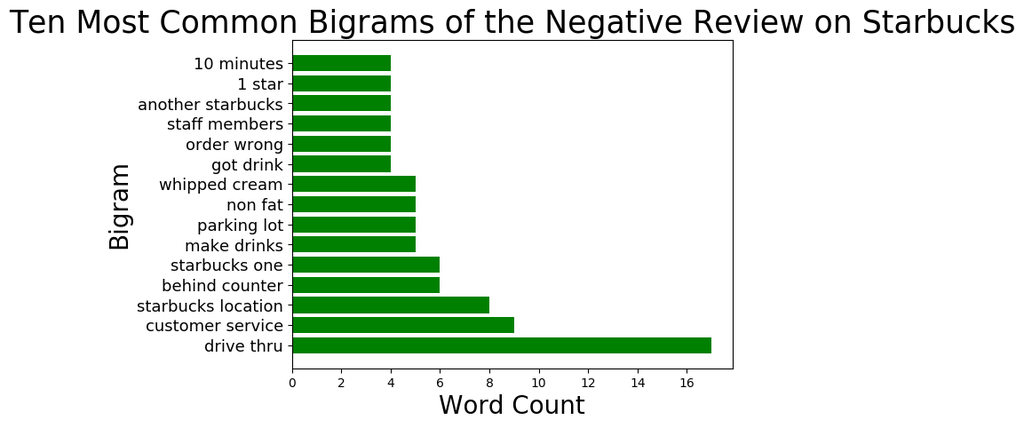

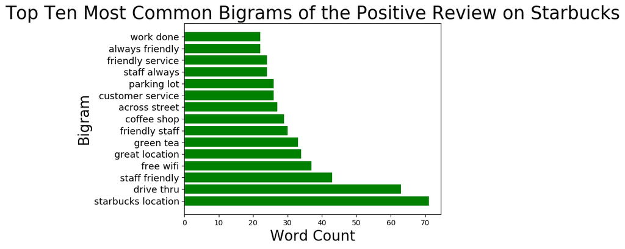

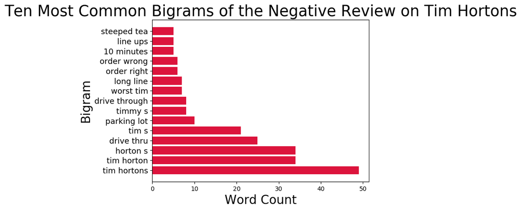

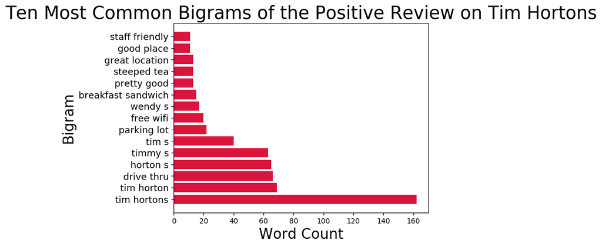

From those bar plots, we can also see that even for the users who have reviewed both establishments, the words they used are still very similar. And most words are the same as previous analysis based on all users, and have been discusses previously. There is one new finding that complaints about "long line", "lines up" appear in the negative word for Tim Hortons. So it turns out that sometimes, there is a long line for Tim Hortons and if you are in a hurry, Starbucks may be a better choice than Tim Hortons.

So in conclusion, if you do not know whether to choose Tim Hortons or Starbucks, here are some advices for you based on the analysis.

- Distance should not be a great factor that affect your choice, because for most Starbucks, there is a Tim Hortons nearby, and the locations of the two establishments are all good.
- Both Tim Hortons and Starbucks have free wifi, friendly staff, and good customer service.
- Both Tim Hortons and Starbucks sometimes mess up orders.
- Tim Hortons is a good place for food, and some recommendations are breakfast sandwich, steeped tea and double double based on the key words in the review. And Starbucks is a good place for having a place to work or rest, and people always find seating area and have work done here.
- Sometimes, there is a long line for Tim Hortons and if you are in a hurry, Starbucks may be a better choice than Tim Hortons.

## Reviews and Businesses

### Number of reviews and star ratings

Sometimes, people are in a hurry and do not have enough time to view reviews, so they simply base on number of reviews and star ratings to determine where to eat or where to shop... But can people only base on one factor to make a decision? For example, can people only look at the number of reviews? Is there a relationship between the number of reviews and star ratings?

I categorized businesses into five groups: businesses with number of reviews less than 100, between 100 to 500, between 500 to 1000, between 1000 to 5000 and greater than 5000. And since there are 9 star rating levels: 1.0, 1.5, 2.0, 2.5, 3.0, 3.5, 4.0, 4.5, 5.0, so I further categorized the star ratings into star rating between 1.0 to 2.0(low stars), star rating between 2.5 to 3.5(average stars) and star rating between 4.0 to 5.0(high stars).

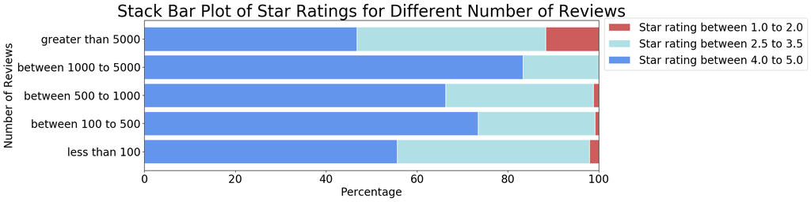

From the plot above, there seems to be no relationship between the number of reviews and star ratings. And for businesses with 1000-5000 reviews, the percentage of businesses with higher star ratings is high, and there is no business with low star ratings. However, for the businesses with more than 5000 reviews, a relatively large proportion of the businesses have low star ratings. So higher number of reviews does not lead to higher star ratings, and when people choose businesses, they cannot only look at the number of reviews, and they need to determine based on both number of reviews and star ratings.

### Business Locations and Number of Reviews, Star Ratings

However, when it comes to the number of reviews, star ratings and business locations, there is a relationship between them.  
First, I plotted all businesses with more than 500 reviews and businesses with 5.0 star on the map, and I squared the area of downtown Toronto on the map based on the latitude and longitude of downtown Toronto.

[figure not shown]

### Map for Businesses with 5.0 Stars

● business with 5.0 star

[figure not shown]

Since the blue square represents downtown Toronto, we can see that in the first map for the businesses with more than 500 reviews, these businesses are mainly concentrated in downtown Toronto. And most of them are in downtown, which indicates that there might be a relationship between location and number of reviews. However, in the second map for the businesses with 5.0 star, they are not concentrated in downtown Toronto, and many of them are outside downtown Toronto. But whether other location factors like flow rates are unknown. So we cannot simply conclude that there is no relationship between the location and star rating, but at least one thing for sure is that there is no relationship between star ratings and distance from downtown.  
Then, to further see the relationship between distance from downtown and number of reviews, I calculated mean review counts on each distance from downtown.

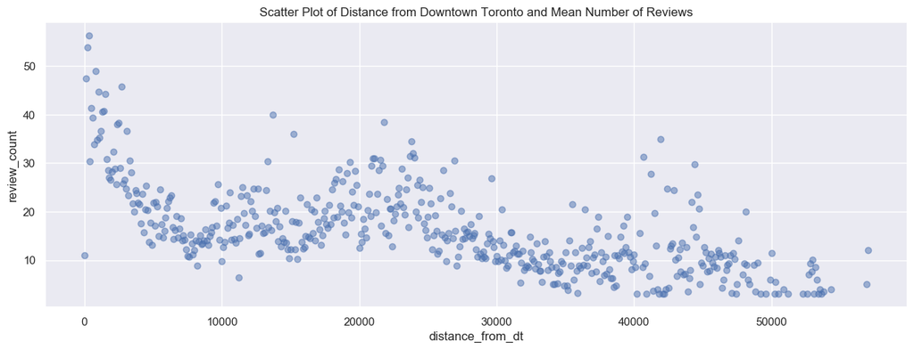

From the scatter plot, there is a negative relationship between the distance from downtown and number of reviews, that is the more the distance from downtown is, the fewer the average review count is. But there is an exception that the review count reached its local maximum when the distance from downtown is around 20km, and one possible reason is that these businesses are in satellite cities like Markham.

## Reviews are Reliable? We Should Follow Whom?

Since it has been reported that there are many fake positive reviews on Yelp, so many users are concerned whether reviews are reliable on Yelp. After I calculated the total number of reviews written by each user, I have found that there is a group of people who are responsible for many reviews in Yelp. There are 3844 reviews among all the reviews in GTA that are written by User CxDOIDnH8gp9KXzpBHJYXw.

```
CxDOIDnH8gp9KXzpBHJYXw    3844
0BBUmH7Krcax1RZgbH4fSA     996
Q9mA60HnY87C1TW5kjAZ6Q     992
U5YQX_vMl_xQy8EQDqlNQQ     978
YBT3EKUNN4IP8m4x7sGu1g     884
Name: user_id, dtype: int64
```

**table for the top 5 users with most number of reviews in dataset for GTA**

So we are very suspicious of the authenticity of these people's reviews. Also since Yelp filter gives preference to established reviewers who have reviewed multiple businesses, so you are very likely to see these people’s reviews. That's why these people’s rating and reviews really matter to most of us.  
To see the quality of these people's reviews, I decided to measure it in two dimensions. One is the average difference of the star given by the user and the star rating of the business to see the quality of star ratings of a user. The other one is the mean number of likes received by each user, and this is to measure the quality of reviews of a user.

If a person always gives stars that are far different from other people, then their stars are not reliable since they may have a very unique taste or their reviews are fake. So I calculated the difference of the star given by the user and the star rating of the business. To find the star rating of the business, I used business_id in review and mapped it into the dataframe for all businesses to find the star rating. Then I have grouped reviews in GTA by user_id and calculated the mean star difference.

Since the dataset is too large to process, so I split them into subdataframes, and process them separately.

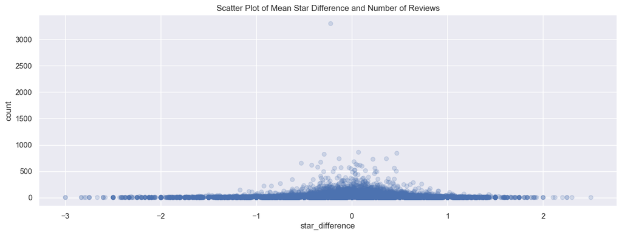

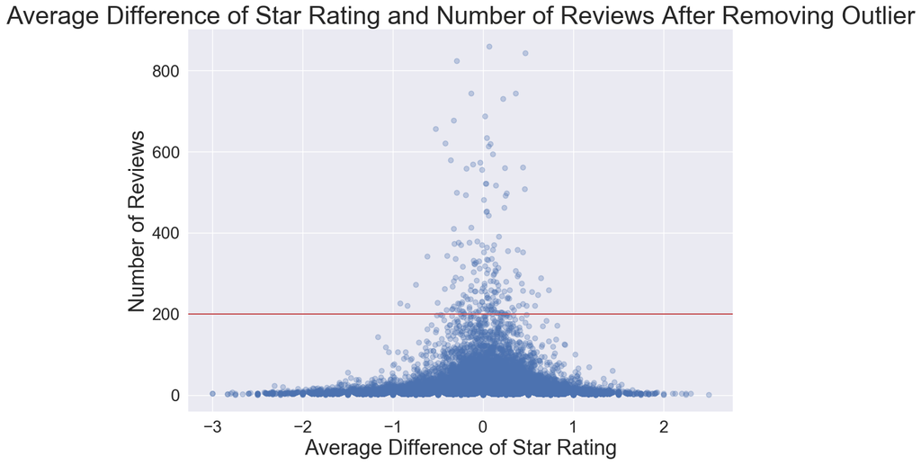

For users who have written more than 200 reviews, their mean star difference is between -1 and 1, which means that their star rating is very similar to the accurate star rating of the business, and in most time, these people give proper star ratings and you may trust their star rating. And this makes sense because some people who have only written few reviews when they are very satisfied with the business, or very angry about it, and that's why many users with low review counts have a large difference of star ratings.

To see the quality of those people's reviews, I focus on the number of useful, cool, or funny received by user, and I calculated the mean number of likes received by each user. Then I ranked people according the number of reviews, and I grouped them into users who ranked top 1% and other users.

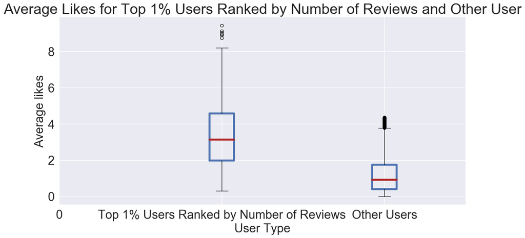

It is obvious that median, first quantile and third quantile of top 1% users are far greater than ordinary users. One possible reason is that these people have more followers and another reason is that Yelp filters give preference to these reviews, so people are more likely to see these reviews. However, no matter what the reason is, one thing for sure is that these people’s reviews are reliable.

In conclusion, users who have written large number of reviews are trustworthy, and we can rely on their reviews and star ratings. And this also means that the Yelp Filter for this part is reliable. Furthermore, since the quality of star ratings and reviews of those people are even better than normal users, so if you do not know to follow whom on Yelp, these users are good choices for you.

# Conclusion

While this dataset is only a subset of the whole dataframes, I was able to give some advice for users that are currently using Yelp and provide some details about businesses and reviews that are not revealed on Yelp.  
Users who love Chinese food should consider Toronto as a good trip destination, and users who have bikes can choose Starbucks for meal.  
For those who have no idea what to choose between Starbucks and Tim Hortons, the location should not be considered as a big factor to influence your choice, and Tim Hortons is a good place for food, while Starbucks is a good place for work and rest.  
If you want to go to popular businesses in GTA, downtown is a good choice for you, but if you like businesses with high quality, in addtion to downtown Toronto, many businesses in other places are also of good quality.  
For people who are responsible for many reviews on Yelp, most of them are reliable and you can trust their ratings and reviews, and even follow them.

All of these are the useful information and advices that people who use Yelp may concern about, but none of them are revealed in the Yelp app. And to some extent, this can help better satisfy their preference for people who use this software to discover businesses, and thus improve their experience

But there are still some limitations for my analysis and we can explore deeper to those questions by using more data.

- We only cover the businesses in some cities and mainly focus on GTA, so some analysis is only limited to people in GTA. And to further explore more business pattern, we need to use data from more cities.
- I did not detect fake reviews, and fake review is also a big problem that many users concern about. In further exploration, we should include this part.
- The number of likes can also be fake in reality, however, I have no way to detect it in my analysis.